💻

# Lecture 7: Multiple Linear Regression

| Dates | @November 22, 2021 |
| --- | --- |
| Type | 📒 Lesson |
| Topic | Graphical RepresentationIntroduction to RLinear Model |
| Link |  |

#### 📚 Recommended reading

| Name | Pages |
| --- | --- |
| ggplot2: Elegant Graphics for Data Analysis | 3-31 |

#### 📂 Files

[output not shown]

# Summary of session

- Linear model
- ggplot2 concepts

# **Background:**

The data set consists of health information on a sample of n = 45 small US cities. The following measures have been recorded, by city:

- death: death rate per 1000 residents
- doctor: doctor availability per 100,000 residents
- hospital: hospital availability per 100,000 residents
- income: annual per capita income in thousands of dollars
- density: population density people per square mile

# **Loading Packages**

```
library(foreign)
library(tidyverse)
library(car) # Remember to install the package 'car' if you do not have it yet!
library(gmodels) # Also install the package 'gmodels' if you do not have it!
library(psych)
library(ggpubr)
library(broom)
```

# **Loading data**

```
url <- 'https://github.com/fans-stats/intro_to_R_stats/blob/main/datasets/health.sav?raw=true'
dataset <- foreign::read.spss(file = url, to.data.frame = TRUE)
dataset <- as_tibble(dataset)
dataset
```

| Title | death<dbl> | doctor<dbl> | hospital<dbl> | income<dbl> | density<dbl> |
| --- | --- | --- | --- | --- | --- |
| Untitled | 7.5 | 70 | 739 | 7.2 | 113 |
| Untitled | 12.8 | 68 | 383 | 7.4 | 57 |
| Untitled | 11.7 | 89 | 634 | 7.6 | 134 |
| Untitled | 9.4 | 82 | 499 | 7.7 | 95 |
| Untitled | 11.3 | 118 | 463 | 7.8 | 35 |
| Untitled | 11.3 | 121 | 728 | 8.2 | 86 |
| Untitled | 10.2 | 74 | 477 | 8.3 | 206 |
| Untitled | 11.6 | 140 | 688 | 8.3 | 80 |
| Untitled | -3.6 | 84 | 288 | 8.4 | 110 |
| Untitled | 8.1 | 154 | 354 | 8.4 | 103 |

# **Some tidyverse concepts**

# **mutate() + ifelse() for creating groups**

```
dataset %>%
  mutate(high_death = ifelse(
    death > mean(death, na.rm = TRUE) + sd(death, na.rm = TRUE),
    yes = TRUE,
    no = FALSE),
    high_income = ifelse(
    income > mean(income, na.rm = TRUE) + sd(income, na.rm = TRUE),
    yes = TRUE,
    no = FALSE)
  )
```

| Title | death<dbl> | doctor<dbl> | hospital<dbl> | income<dbl> | density<dbl> | high_death<lgl> | high_income<lgl> |
| --- | --- | --- | --- | --- | --- | --- | --- |
| Untitled | 7.5 | 70 | 739 | 7.2 | 113 | FALSE | FALSE |
| Untitled | 12.8 | 68 | 383 | 7.4 | 57 | TRUE | FALSE |
| Untitled | 11.7 | 89 | 634 | 7.6 | 134 | TRUE | FALSE |
| Untitled | 9.4 | 82 | 499 | 7.7 | 95 | FALSE | FALSE |
| Untitled | 11.3 | 118 | 463 | 7.8 | 35 | FALSE | FALSE |
| Untitled | 11.3 | 121 | 728 | 8.2 | 86 | FALSE | FALSE |
| Untitled | 10.2 | 74 | 477 | 8.3 | 206 | FALSE | FALSE |
| Untitled | 11.6 | 140 | 688 | 8.3 | 80 | FALSE | FALSE |
| Untitled | -3.6 | 84 | 288 | 8.4 | 110 | FALSE | FALSE |
| Untitled | 8.1 | 154 | 354 | 8.4 | 103 | FALSE | FALSE |

# **Group_by() + Summarise() for multiple variables**

```
dataset %>%
  mutate(high_death = ifelse(
    death > mean(death, na.rm = TRUE) + sd(death, na.rm = TRUE),
    yes = TRUE,
    no = FALSE),
    high_income = ifelse(
    death > mean(income, na.rm = TRUE) + sd(income, na.rm = TRUE),
    yes = TRUE,
    no = FALSE)
  ) %>%
  group_by(high_death, high_income) %>%
  summarise(min_doctor = min(doctor),
            max_doctor = max(doctor),
            mean_doctor = mean(doctor)) %>%
  ungroup()
```

| high_death<lgl> | high_income<lgl> | min_doctor<dbl> | max_doctor<dbl> | mean_doctor<dbl> |
| --- | --- | --- | --- | --- |
| FALSE | FALSE | 60 | 196 | 111.5484 |
| FALSE | TRUE | 80 | 238 | 126.5455 |
| TRUE | TRUE | 68 | 176 | 111 |

3 rows

# **pivot_wider() and pivot_longer()**

```
dataset %>%
  mutate(level_death = ifelse(
    death > mean(death, na.rm = TRUE) + sd(death, na.rm = TRUE),
    yes = 'high',
    no = 'low')
  ) %>%
  group_by(level_death) %>%
  summarise(mean_doctor = mean(doctor)) %>%
  ungroup() %>%
  pivot_wider(names_from = level_death, values_from = mean_doctor)
```

| Title | high<dbl> | low<dbl> |
| --- | --- | --- |
| Untitled | 111 | 115.4762 |

```
dataset %>%
  mutate(level_death = ifelse(
    death > mean(death, na.rm = TRUE) + sd(death, na.rm = TRUE),
    yes = 'high',
    no = 'low')
  ) %>%
  group_by(level_death) %>%
  summarise(mean_doctor = mean(doctor)) %>%
  ungroup() %>%
  pivot_wider(names_from = level_death, values_from = mean_doctor) %>%
  pivot_longer(cols = c('high', 'low'),
               names_to = 'level_death',
               values_to = 'value')
```

| level_death<chr> | value<dbl> |
| --- | --- |
| high | 111 |
| low | 115.4762 |

# **Task 1**

First, identify the type of each variable in the dataset.

- death is a numerical continuous variable
- doctor is a numerical discrete variable
- hospital is a numerical discrete variable
- income is a numerical continuous variable
- density is a numerical discrete variable

# **Task 2**

Use the appropriate descriptive indices to identify potential typos and if so, clean the dataset. Use the space below to keep a record of the typos you found and then delete them to create a “clean data set”.

```
dataset %>%
  ggplot(aes(x = death)) +
    geom_histogram()
```

[figure not shown]

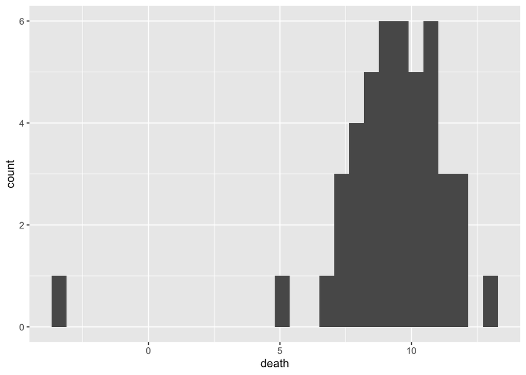

```
dataset %>%
  ggplot(aes(x = density)) +
    geom_histogram()
```

[figure not shown]

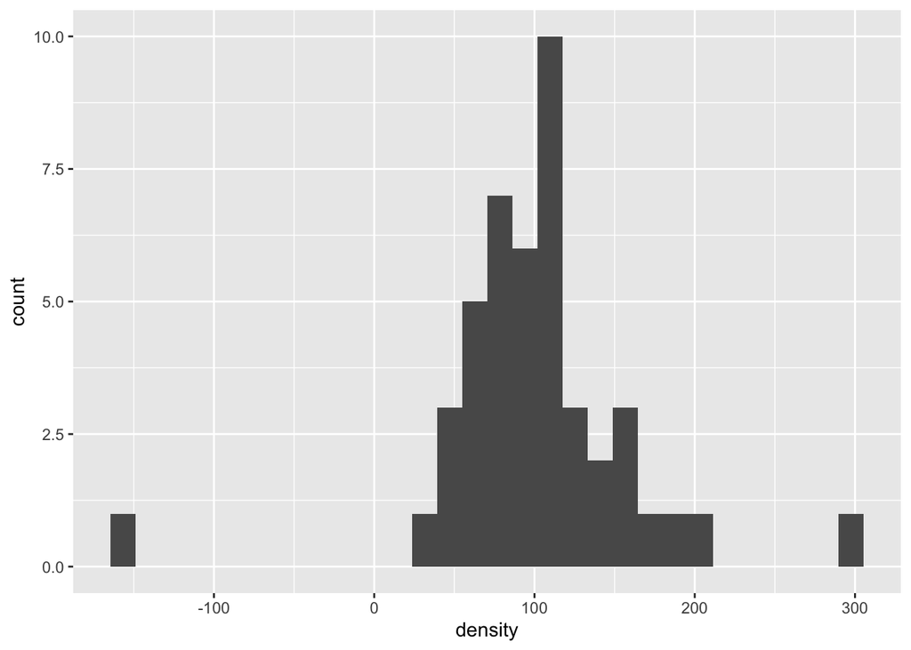

```
# min(dataset$death)# min(dataset$density)


dataset$death[dataset$death < 0] <- NA
dataset$density[dataset$density == -162] <- NA
```

# **Task 3**

People from different cities want to claim a lack of doctors in their area. Before formulating their claim to the government, they would like to investigate the causes of the lack of doctors. They hypothesise that the number of hospitals and income per capita is associated with the number of available doctors. Investigate if the sample supports their hypothesis.

1. Use the appropriate R command to build a multiple linear regression model that can be used to investigate the hypothesis.

```
dataset %>%
  lm(formula = doctor ~ hospital + income) %>%
  summary()
```

```
##
## Call:
## lm(formula = doctor ~ hospital + income, data = .)
##
## Residuals:
##     Min      1Q  Median      3Q     Max
## -62.361 -23.487   1.746  17.256  79.627
##
## Coefficients:
##              Estimate Std. Error t value Pr(>|t|)
## (Intercept) -60.15900   45.81931  -1.313  0.19632
## hospital      0.09954    0.02388   4.169  0.00015 ***
## income       13.27318    5.01168   2.648  0.01134 *
## ---
## Signif. codes:  0 '***' 0.001 '**' 0.01 '*' 0.05 '.' 0.1 ' ' 1
##
## Residual standard error: 30.61 on 42 degrees of freedom
## Multiple R-squared:  0.4176, Adjusted R-squared:  0.3899
## F-statistic: 15.06 on 2 and 42 DF,  p-value: 1.172e-05
```

1. Write down the equation of the multiple linear regression model in terms of y, x1, x2 and the error term.

𝑦y = -60.159 + 0.1𝑥1x1 + 13.273𝑥2x2 + 𝜖ϵ

1. Explain what y, x1, x2, , , and represent in this context.

   𝛽0

   β0

   𝛽1

   β1

   𝛽2

   β2

   𝜖

   ϵ

𝑦y: is the doctor availability per 100,000 residents

𝑥1x1: is the hospital availability per 100,000 residents

𝑥2x2: is the annual per capita income in thousands of dollars

𝛽0β0: -60.159 would be the extrapolated doctor availability per 100,000 residents in a city with 0 hospitals and 0 income. (Clearly not a meaningful number in this context.)

𝛽1β1: a 1 hospital increase is associated with 0.1 doctors increase per 100,000 increase for a given per capita income.

𝛽2β2: a 1 thousand dollars’ increase in income per capita is associated with an increase of 13.273 doctors per 100,000 residents for a given number of hospitals.

𝜖ϵ: is the residual value between the predicted value on the regression plane, and the observed value.

# **Task 4**

```
dataset %>%
  lm(formula = doctor ~ hospital + income) %>%
  augment() %>%

  ggplot(aes(x = hospital, y = doctor)) +
    geom_point() +
    theme_bw()
```

[figure not shown]

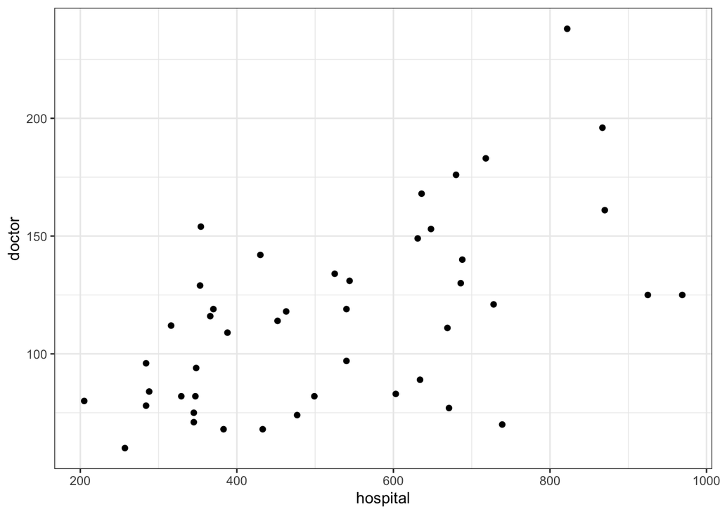

There is a positive linear relationship between the two variables. Higher hospital availability is associated with higher doctor availability.

```
dataset %>%
  lm(formula = doctor ~ hospital + income) %>%
  augment() %>%

  ggplot(aes(x = income, y = doctor)) +
    geom_point() +
    theme_bw()
```

[figure not shown]

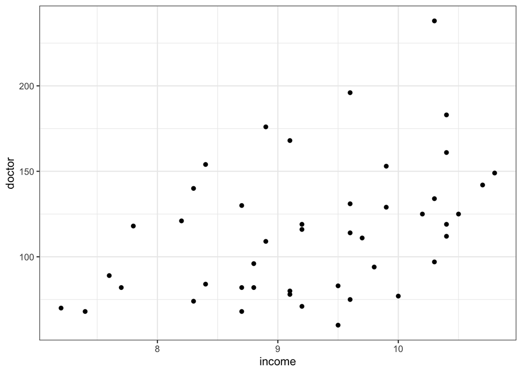

There is a positive linear relationship between the two variables. Higher annual per capita income is associated with higher doctor availability.

1. The error terms 𝜀 are normally distributed

```
dataset %>%
  lm(formula = doctor ~ hospital + income) %>%
  augment() %>%

  ggplot(aes(x = .std.resid)) +
    geom_histogram(binwidth = 0.5) +
    theme_bw()
```

[figure not shown]

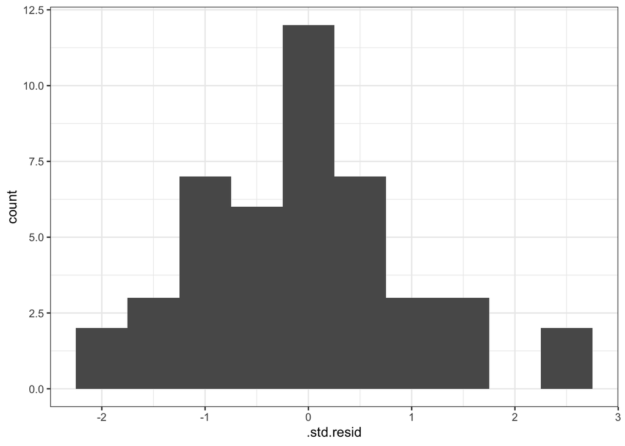

The residuals 𝜖ϵ are normally distributed. We can see in the histogram that the distribution is bell-shaped and symmetrical around the mean.

1. The error terms have the same variance irrespective of the size of the predicted outcome (i.e., variance does not depend on x1 or x2), also called “homoscedasticity”.

```
dataset %>%
  lm(formula = doctor ~ hospital + income) %>%
  augment() %>%

  ggplot(aes(x = .fitted, y = .std.resid)) +
    geom_point() +
    theme_bw()
```

[figure not shown]

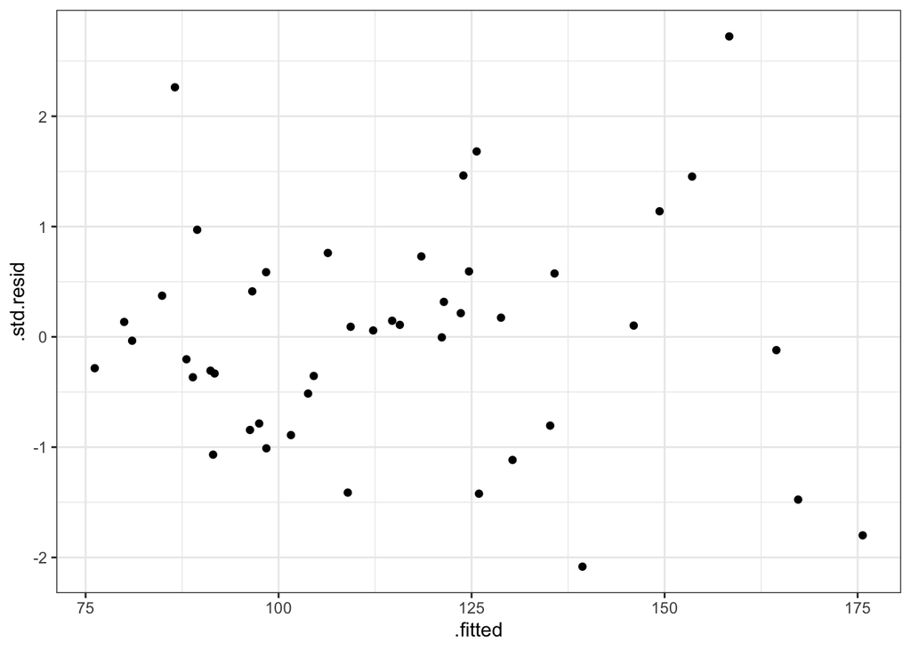

# **Task 5**

Provided the three assumptions to carry out statistical inference were met for the model derived in Task 3, consider testing some hypotheses next:

1. Write the null and the alternative hypotheses for the regression coefficient and report on the results.

   𝛽1

   β1

𝐻0H0: 𝛽1β1 coefficient equals 0 𝐻𝛼Hα: 𝛽1β1 coefficient is different than 0

We can infer the value of 𝛽1β1 = 0.100 for the whole population, as the 𝑝p value is less than 0.05 (𝑝p < 0.001). Therefore, we reject the null hypothesis of no association between the two variables and we infer that the number of available doctors is associated with the number of hospitals. We estimate that a 1 hospital increase is associated with a 0.1 doctor availability increase, for a given per capita income.

1. Write the null and the alternative hypotheses for the regression coefficient and considering that the model assumptions for inference are met, report on the results.

   𝛽2

   β2

𝐻0H0: 𝛽2β2 coefficient equals 0 𝐻𝛼Hα: 𝛽2β2 coefficient is different than 0

We can infer the value of 𝛽2β2 = 13.273 for the whole population, as the 𝑝p value is less than 0.05 (𝑝p = 0.011). Therefore, we reject the null hypothesis of no association between the two variables and we infer that the number of available doctors is associated with the income per capita. We estimate that a 1 thousand dollars increase in income per capita between cities is associated with an increase of 13.273 doctors per 100,000 population, for a given hospital availability.

1. Report and interpret the 95% confidence interval for .

   𝛽1

   β1

The 95% confidence interval for 𝛽1β1 is [0.051, 0.148]. The estimated value for 𝛽1β1 in the 95% of samples extracted from the population will belong to this interval. This interval excludes the null value of 0, also telling us that the b1 parameter is significant, i.e. there is a significant relationship between hospital and doctor availability.

1. Report and interpret the 95% confidence interval for .

   𝛽2

   β2

The 95% confidence interval for 𝛽2β2 is [3.159, 23.387]. The estimated value for 𝛽2β2 in the 95% of samples extracted from the population will belong to this interval. This interval excludes the null value of 0, also telling us that the 𝛽2β2 parameter is significant, i.e. there is a significant relationship between income per capital and doctors availability.

```
dataset %>%
  lm(formula = doctor ~ hospital + income) %>%
  confint()
```

```
##                     2.5 %     97.5 %
## (Intercept) -152.62610355 32.3081018
## hospital       0.05135345  0.1477174
## income         3.15920373 23.3871473
```

# **Task 6**

Use the model to predict the doctor availability per 100,000 residents given that the number of hospitals is 575 and the income per capita is 10.1 thousand dollars. Report and interpret a 95% confidence interval for the predicted value.

```
new.measure <- tibble(
  hospital = c(575),
  income = c(10.1)
)

dataset %>%
  lm(formula = doctor ~ hospital + income) %>%
  predict.lm(newdata = new.measure,
             interval = "prediction")
```

```
##        fit      lwr      upr
## 1 131.1329 68.12705 194.1388
```

# **Task 7**

```
dataset %>%
  lm(formula = doctor ~ hospital + income) %>%
  summary()
```

```
##
## Call:
## lm(formula = doctor ~ hospital + income, data = .)
##
## Residuals:
##     Min      1Q  Median      3Q     Max
## -62.361 -23.487   1.746  17.256  79.627
##
## Coefficients:
##              Estimate Std. Error t value Pr(>|t|)
## (Intercept) -60.15900   45.81931  -1.313  0.19632
## hospital      0.09954    0.02388   4.169  0.00015 ***
## income       13.27318    5.01168   2.648  0.01134 *
## ---
## Signif. codes:  0 '***' 0.001 '**' 0.01 '*' 0.05 '.' 0.1 ' ' 1
##
## Residual standard error: 30.61 on 42 degrees of freedom
## Multiple R-squared:  0.4176, Adjusted R-squared:  0.3899
## F-statistic: 15.06 on 2 and 42 DF,  p-value: 1.172e-05
```

𝑅2R2 is 0.418. Therefore, 41.8% of the variance in the number of available doctors is “explained” by the annual per capita income and hospital availability. 𝑅2R2 adjusted is 0.39, saying 39% of the variance in the number of available doctors is “explained” by the annual per capita income and hospital availability. This value should be used rather than the unadjusted 𝑅2R2 as it adjusts for the number of predictors, and is better to use when we are comparing models with different numbers of predictors.